# Phylogenetic Least Squares

# Testing for corellations using phylogenetic least squares

## Why?

When species are your unit of inference and you undertake standard statistical analyses, you are implicitly assuming that the evolutionary distance between all species is equal (a.k.a. a phylogenetic “bush” rather than a tree ) - we know this is not true!

Phylogenetic least squares allows you to explore linear relationships between variables contingent upon covariances extrapolated from the phylogenetic tree.

## Example

This is based on a paper that a UQ undergraduate student, [Katja Kasimatis](https://oregon.arcsfoundation.org/news/congratulations-2021-dobzhansky-prize-winner), wrote looking at variation in egg sizes for coral reef fishes (Kasimatis & Riginos 2016: Coral Reefs). She went on to get her PhD at the University of Oregon and was awarded the Dobzhansky Prize, one of the highest award for a finishing PhD student in evolutionary biology - way to go Katja!

[figure not shown]

```r
library(ape)
library(geiger)
library(nlme)

fishdata <- read.csv("fishtraits_geography.csv", header=TRUE, row.names=1)  #data file
fishtree<-read.tree("Fish_chronogram.nex")
plot(fishtree)
```

### Prepping the data

These example data files have been well prepared. Most likely yours will not. See `BlombergK.html` for some general tips on getting the taxa names in your data file and tree to match. Make sure to check for branch length also!

### Analyses

PGLS can be used like any regression. You can model the effect on one predictive variable on one response variable, or you can make a more complex multiple regression model.

```r
#reduce the tree to match your data
tree_reduced <-treedata(fishtree, fishdata, sort=TRUE, warnings=TRUE)  #lots of warnings!
```

[output not shown]

[output cut: 21 more lines]

[output not shown]

[output not shown]

[output cut: 8 more lines]

[output not shown]

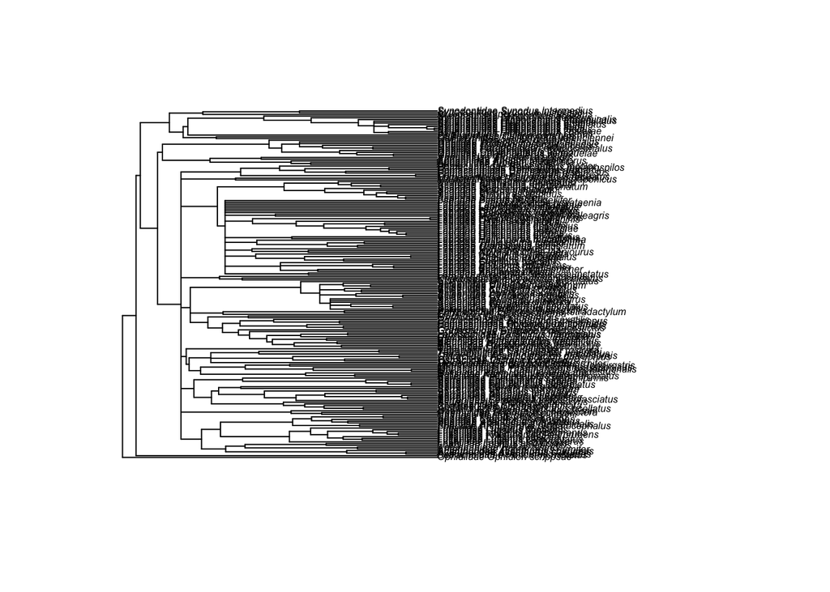

```r
plot(tree_reduced$phy, cex = 0.5)  #simpler tree than uploaded tree - many branches pruned
```

```r
fishdata_reduced<-fishdata[row.names(tree_reduced$data),]  #simplified data file

#now derive a covariance matrix under the assumption of Brownian motion proportional to the tree
bm.tree<-corBrownian(phy=tree_reduced$phy)

#testing with PGLS - simple prediction: body size of fish predicts egg size
univariatePGLS<-gls(log(vol)~sl, correlation=bm.tree, data=fishdata_reduced)
summary(univariatePGLS)
```

```
## Generalized least squares fit by REML
##   Model: log(vol) ~ sl
##   Data: fishdata_reduced
##        AIC      BIC    logLik
##   572.9257 582.8207 -283.4629
##
## Correlation Structure: corBrownian
##  Formula: ~1
##  Parameter estimate(s):
## numeric(0)
##
## Coefficients:
##                  Value Std.Error   t-value p-value
## (Intercept) -0.6673109 0.4684036 -1.424649  0.1558
## sl           0.0091867 0.0021527  4.267488  0.0000
##
##  Correlation:
##    (Intr)
## sl -0.131
##
## Standardized residuals:
##        Min         Q1        Med         Q3        Max
## -2.4562907 -1.1312705 -0.8097445 -0.3714583  3.8036224
##
## Residual standard error: 1.374412
## Degrees of freedom: 202 total; 200 residual
```

```r
anova(univariatePGLS, test="F")  #this test asks how better is the model than one that is based on an intercept only, that is, we do not use body size as predictor
```

```
## Denom. DF: 200
##             numDF   F-value p-value
## (Intercept)     1  0.762358  0.3836
## sl              1 18.211457  <.0001
```

```r
## -> body size highly significant!

#testing with PGLS - multiple predictions: egg type and latitude and their interactions
PGLSmodel<-gls(log(vol)~egg.type*latitude, correlation=bm.tree, data=fishdata_reduced)
summary(PGLSmodel)  #complicated results because there are a lot of categories
```

```
## Generalized least squares fit by REML
##   Model: log(vol) ~ egg.type * latitude
##   Data: fishdata_reduced
##        AIC      BIC    logLik
##   575.0112 607.6381 -277.5056
##
## Correlation Structure: corBrownian
##  Formula: ~1
##  Parameter estimate(s):
## numeric(0)
##
## Coefficients:
##                                              Value Std.Error    t-value p-value
## (Intercept)                              0.1790729 0.5608619  0.3192815  0.7499
## egg.typeegg.scatterer                   -2.3356158 1.0906442 -2.1415011  0.0335
## egg.typepelagic                         -0.7521775 0.4520378 -1.6639702  0.0977
## latitudetemperate                        0.7654596 0.3812920  2.0075415  0.0461
## latitudetropical                         0.0044751 0.2252996  0.0198627  0.9842
## egg.typeegg.scatterer:latitudetemperate -0.2133778 1.0698265 -0.1994509  0.8421
## egg.typepelagic:latitudetemperate       -0.8514288 0.5152066 -1.6525970  0.1000
## egg.typeegg.scatterer:latitudetropical   0.3894406 0.9269147  0.4201472  0.6748
## egg.typepelagic:latitudetropical        -0.2773651 0.2672002 -1.0380424  0.3005
##
##  Correlation:
##                                         (Intr) egg.t. egg.ty lttdtm lttdtr
## egg.typeegg.scatterer                   -0.218
## egg.typepelagic                         -0.530  0.346
## latitudetemperate                       -0.230  0.135  0.345
## latitudetropical                        -0.223  0.121  0.288  0.335
## egg.typeegg.scatterer:latitudetemperate  0.082 -0.730 -0.122 -0.356 -0.119
## egg.typepelagic:latitudetemperate        0.171 -0.108 -0.356 -0.749 -0.249
## egg.typeegg.scatterer:latitudetropical   0.054 -0.774 -0.069 -0.081 -0.243
## egg.typepelagic:latitudetropical         0.190 -0.098 -0.319 -0.284 -0.843
##                                         egg.typgg.scttrr:lttdtm
## egg.typeegg.scatterer
## egg.typepelagic
## latitudetemperate
## latitudetropical
## egg.typeegg.scatterer:latitudetemperate
## egg.typepelagic:latitudetemperate        0.266
```

[output cut: 12 more lines]

```
## egg.typeegg.scatterer
## egg.typepelagic
## latitudetemperate
## latitudetropical
## egg.typeegg.scatterer:latitudetemperate
## egg.typepelagic:latitudetemperate
## egg.typeegg.scatterer:latitudetropical
## egg.typepelagic:latitudetropical         0.205
##
## Standardized residuals:
##        Min         Q1        Med         Q3        Max
## -2.2925602 -0.9568840 -0.6145851 -0.2759798  3.3784025
##
## Residual standard error: 1.389872
## Degrees of freedom: 202 total; 193 residual
```

```r
anova(PGLSmodel, test="F")  # look at p values here - only egg type is significant, so latitude and interaction between latitude and egg type not significant!
```

```
## Denom. DF: 193
##                   numDF  F-value p-value
## (Intercept)           1 0.745492  0.3890
## egg.type              2 5.993939  0.0030
## latitude              2 2.260274  0.1071
## egg.type:latitude     4 0.968887  0.4257
```